# lecture-05-qualitative-observational

## M303 Qualitative and Observational Methods

FALL 2026 · LECTURE 05

M303

Qualitative and Observational Methods

Observe behavior, listen deeply, and uncover the meaning behind consumer decisions.

## Where we are

01

Fundamentals of Data Analysis

•

Preparation of data for analysis

•

Descriptive stats, simple and cross-tabs

04

Hypothesis testing

05

Correlation and regression analysis

06

Secondary data

07

Primary data

•

Observational and Qualitative Methods

•

Surveys

10

Sampling

11

Problem

12

Formulation

13

Research

14

Design

15

Data

16

Collection

17

Data Analysis &

18

Recommendation

19

Preliminary stages of MR

•

Problem → actionable management problem → research objectives → research questions → hypotheses

21

Decide on the type of research

•

Exploratory, descriptive & causal

## Learning Objectives

01

You should be able to

•

Understand differences between observing and asking.

•

Understand the pros and cons of observing over asking.

•

Understand the types and characteristics of qualitative methods of primary data collection.

## Prior-class review

01

In primary research, the data are collected by you or by a company you hire.

02

Surveys, interviews, focus groups, observations and/or experiments can be used to collect secondary data.

03

Secondary data might be qualitative, but the primary data has to be quantitative.

04

The main advantage of secondary data is its low cost of acquisition.

05

Secondary data might come from internal and external sources.

06

When conducting secondary research, you should first start with external sources, and then check the internal sources.

07

External secondary data might come either from published data or standardized sources.

08

Among the standardized sources of data, retail store audits are the best source to understand the preferences of customers.

09

All the discussed sources of standardized data might be used to understand the sales/shares of brands in the market.

10

Home audit approach and the mail diary method are the two ways to collect scanner data.

11

Selection bias, mortality and testing effects bias the reliability of retail store audits.

12

One can conduct real-time sales analysis by using retail store audits.

13

Single source systems allow firms to measure the effectiveness of different advertising messages on the purchase behavior of customers.

## Primary Data Collection Methods

01

Observation

•

Human

•

Machine

04

Questioning

•

Qualitative

•

Focus groups

•

In-depth interviews

•

Projective techniques

•

Quantitative

•

Survey research

•

Experiments

## How to collect data?

01

Observe

05

Ask

## What is Observation?

01

A systematic process of recording patterns of occurrences or behaviors without normally communicating with the people involved.

02

"You see, but you do not observe."

03

— Sherlock Holmes

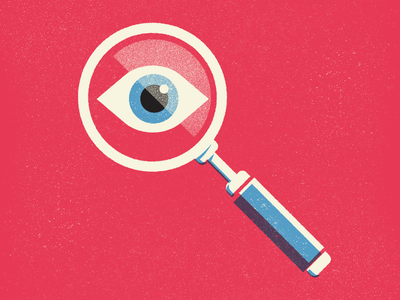

## What are the pros and cons of observation over asking?

01

Advantages of observation over asking

02

Disadvantages of observation over asking

03

No communication with the respondent

04

No self-report distortions

05

No need to rely on respondents’ memory

06

Nonverbal behavior can be recorded

07

Certain data can be collected more quickly

08

Environmental conditions can be recorded

09

Cognitive phenomena can’t be observed

10

Observer bias can distort interpretation

11

Not all activities can be recorded

12

Possible invasion of privacy

13

Observed behavior may change because people know they are being watched

## Example 1: Mystery Shoppers

01

What behaviors can a mystery shopper observe that a customer survey might miss?

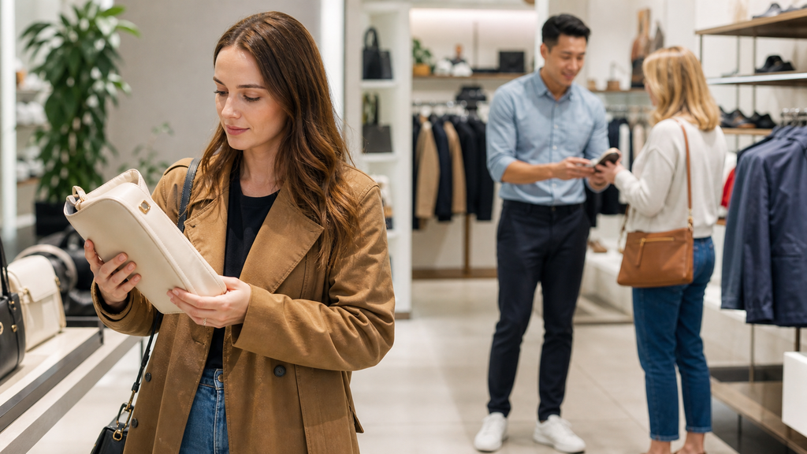

[Play source video ↗](https://www.youtube.com/watch?v=Rsth2qvWFfw)

## Example 2: Eye Tracking

01

Where does a shopper’s attention go—and what do they overlook?

[figure not shown]

[Play source video ↗](https://www.youtube.com/watch?v=lo_a2cfBUGc)

## Example 3: Functional Magnetic Resonance Imaging (fMRI)

01

fMRI is a functional neuroimaging procedure that measures brain activity by detecting associated changes with blood flow (source: Wikipedia).

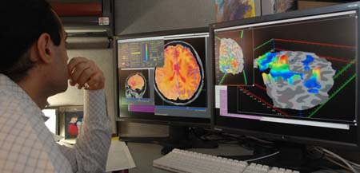

## Example 4: Online Observations: Cookies

01

Cookies and related digital traces can record browsing, search, cart, and purchase behavior without relying on a respondent's memory.

02

Researchers must balance observational value with consent, transparency, and privacy safeguards.

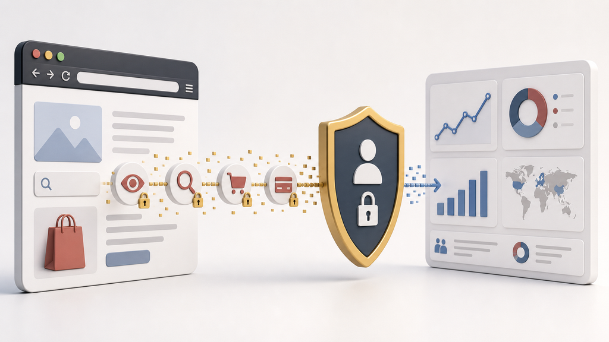

## What are qualitative methods?

01

Qualitative methods:

•

What is in a consumer’s mind?

•

Get a better idea about things that can’t be directly observed and measured.

•

Feelings, thoughts, intentions, experiences, motives etc.

05

Some information cannot be gathered directly through a formal method such as a survey; therefore, qualitative methods may be preferable.

•

Example: Buying a luxury car to overcome a feeling of inferiority

•

If you ask why the person purchased this car, they might say: I got a great deal, or my old car was falling apart.

## What are the major types of qualitative methods?

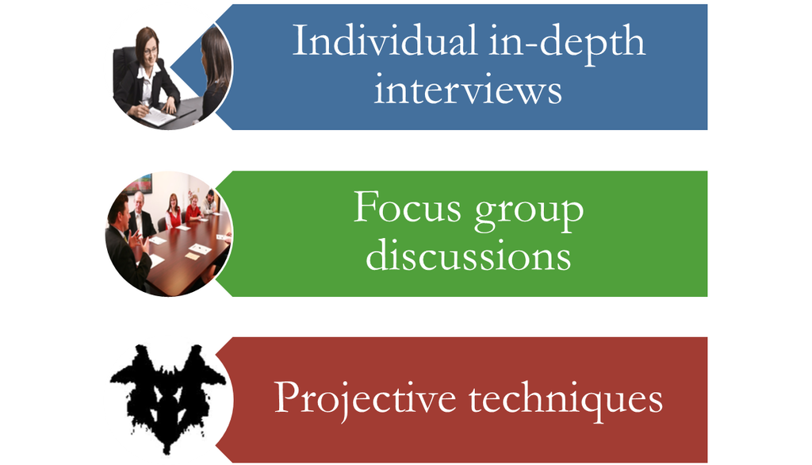

## Qualitative method: Individual In-depth Interviews

01

Nondirective interviews

•

Respondent is given the maximum freedom to respond

•

As the interviewer you have to

•

establish a sympathetic relationship with the respondent

•

probe to clarify and elaborate on the respondent’s answers without biasing them

•

have the skill of guiding the discussion back to the topic outline

•

pursue reasons behind the answers

08

Semi-structured or focused individual interviews

•

Covers a specific list of topics or sub-areas

•

Especially effective with busy executives, technical experts, and thought leaders

## What are the commonly used techniques in IDI?

01

Laddering

•

Step-by-step probing to reach the question of interest

•

Products → product characteristics → user needs

•

Example: identifying the important factors in the smartphone choice

•

Which smartphone brand do you use?

•

Why do you like it?

•

Why is the app store so important?

08

Symbolic analysis

•

Analyze the symbolic meaning of objects by comparing them with opposites

•

Example: identifying the importance of your smartphone

•

What would happen if you had no smartphone?

12

Due to its app store.

13

Many apps I use are only available on iPhone, but not on Android devices.

14

iPhone.

## What are the commonly used techniques in IDI?

01

Hidden issue

•

Understand respondents’ feelings about sensitive issues in their lives

•

Ask individuals to construct specific “best case” and “worst case” scenarios so that their daydreams, anxieties and hopes are brought to the surface

•

Examples:

•

What was the happiest time in your life?

•

What would you do with your time if you were given $1 million?

## Qualitative method: Focus Groups

01

A small number of participants who are led by a moderator have an in-depth discussion about one particular topic or concept

02

Usually consists of 8–12 participants

03

Emphasis on group dynamics, interaction, and open discussion

•

One response can generate additional ideas from other people in the group

•

Interaction between group members can be observed

•

More in-depth information about consumer preferences or feelings can be obtained

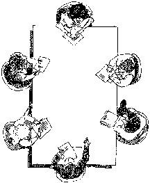

## A Focus Group Example

01

What can a moderator learn from the interaction among participants?

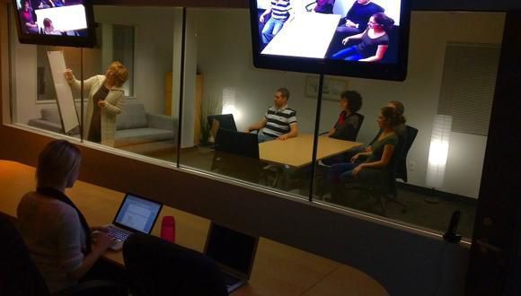

[Play source video ↗](http://www.youtube.com/watch?v=qC_4uF2bHJA)

## How popular are Focus Groups?

01

Historical source-deck snapshot: focus groups were the most widely used qualitative method in more than 50% of marketing research firms

02

The same snapshot reported nearly 900 facilities and more than 1,000 professional moderators in the U.S.

## What are the key elements of Focus Groups?

01

Moderator

•

Person hired by the client to lead the group

•

Needs excellent communication and organizational skills

04

Discussion guide

•

A written outline of topics to be covered during the discussion

06

Focus group length

•

90 minutes on average

•

More questions less time to discuss each question

## How to conduct a Focus Group study?

01

### Prepare

Select a focus-group facility and recruit the participants.

02

### Prepare

Select a moderator and create a discussion guide.

03

### Implement

Conduct the group discussion.

04

### Finalize

Prepare the focus-group report.

## Focus group execution principles

PLAN AND RECRUIT

01You can never do too much planning for a focus group.

02Manage recruitment actively to get the right people into the groups.

03Do not prejudge participants based on physical appearance.

MODERATE AND COORDINATE

04The best moderators bring objectivity and expertise to a project.

05Achieving the research objectives alone does not guarantee a successful group project.

06The moderator and client should coordinate at every stage.

07Client observers should be thoroughly briefed on the research objectives before the sessions.

INTERPRET AND REPORT

08Do not conduct more groups than the research objective requires.

09One important moderator service is a fast report turnaround.

10The most valuable service is objective interpretation—even when the conclusion is not what the client hoped to hear.

## What are the Pros and Cons of Focus Groups?

01

Pros:

•

Getting in-depth information

•

Enables complex issues to be discussed

•

Process highlights differences between consumers

05

Cons:

•

Results not directly quantifiable

•

Difficulty in getting attendees

•

Minority viewpoints may not be heard or may be exaggerated

•

Requires a skilled moderator

## Qualitative method: Projective Techniques

01

When do direct questions fail?

•

The issue is unimportant to the respondent

•

Do you prefer the packaging of Colgate or Crest? Kleenex or Puffs?

•

Group norms, social pressures are significant

•

Do you believe men have to be breadwinners of their families?

•

Consumer doesn’t want to appear ignorant

•

Do you agree or disagree with Senator Helm’s stand on aid to Russia?

•

Need for privacy

•

Have you been treated for mental illness?

•

Which of the following drugs have you tried?

•

Have you ever cheated on income taxes?

•

Respondent may not be fully aware of their “true” motivation

•

Why did you buy a BMW?

## What are the different types of Projective Techniques?

01

Presentation of an ambiguous, unstructured object, activity, or person that a respondent is asked to interpret and explain.

02

Categories of Projective Techniques

•

Word Association

•

Completion Test

•

Picture Interpretation

•

Third Person Techniques

•

Role Playing

•

Case Studies

•

Other Projective Techniques like Photo Sort., Pictured Aspirations Technique (PAT), etc.

## Projective technique:

01

Word Association

02

The researcher presents a word, term, brand name, or product

03

The respondent immediately gives their top-of-mind thought

04

If the respondent fails to answer within 3 seconds, some emotional involvement with the word is assumed

05

Used to select brand names, advertising campaign themes or slogans

06

Example: Apple

•

Design -- ; Quality -- ; Service --; Price --

## Projective technique:

01

Completion Test

02

Used in conjunction with word-association tests

03

Provides more structure than a word-association test

04

The respondent receives an incomplete story or set of sentences and is asked to complete it.

05

Example: People who ride motorcycles are…

•

Free, independent people who enjoy the outdoors and doing things

•

Scary and are usually criminals or at least some type of gang

•

Often professionals—such as lawyers, doctors, and businesspeople—not people you would normally think of as bikers

## Projective technique: Picture Interpretation

01

Also called Thematic Apperception Test (TAT)

02

Respondents are shown one or more pictures where consumers and products are in the center of attention

03

Subjects are asked what is happening in the pictures

04

Real photos or drawings can be used

## Picture interpretation: discussion prompts

01

What are they doing? Where are they? What will happen next? What are they drinking? What do the drinks mean to them?

02

Example: Picture Interpretation

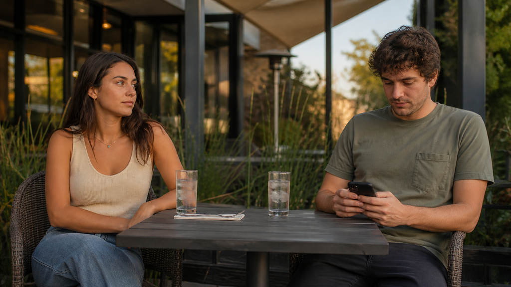

## Major Limitations of Qualitative Methods

01

Potential for the results to be misinterpreted

02

Results are not necessarily representative of the whole population

03

Moderator or interviewer's role is extremely critical and can lead to ambiguous or misleading results

## In-Class Activity

01

Think about what kind of qualitative/observational methods you can use to study the problem/opportunity from your Assignment 1.

## To sum up

01

Observation versus asking

•

Pros and Cons of observing over asking

03

Qualitative primary data collection methods

•

In-depth interviews

•

Focus groups

•

Projective techniques

## Next class

01

Issues in Data Collection

02

Survey Methods

03

Exam 1 schedule: check Canvas